# filter-cmd.tcl documentation

Detlef Groth, Caputh-Schwielowsee, Germany

Mär 21, 2025

filter-abc - filter-cmd - filter-dot - filter-emf - filter-eqn - filter-julia - filter-kroki - filter-mmd - filter-mtex - filter-pic/dpic - filter-pik  
filter-pipe - filter-puml - filter-rplot - filter-sqlite - filter-tcrd - filter-tcl - filter-tdot - filter-tsvg

Documentation: Pantcl filter documentation - Pantcl tutorial - Pantcl Readme - Pantcl Gui

## Name

*filter-cmd.tcl* - Filter which can be used to execute terminal applications using the Tcl filter driver `pantcl.bin` and showing or hiding the output.

## Usage

The conversion of the Markdown documents via Pandoc should be done as follows:

```
pandoc input.md --filter pantcl.bin -s -o output.html
```

The file `filter-cmd.tcl` is not used directly but sourced automatically by the `pantcl.bin` file. If code blocks with the `.cmd` marker are found, the contents in the code block is processed via standard shell as command line application.

The following options can be given via code chunks or in the YAML header.

To change the defaults the YAML header can be used. Here an example to change the default results option to hide.

```
 ----
 title: "filter-cmd.tcl documentation"
 author: "Detlef Groth, Caputh-Schwielowsee, Germany"
 date: 2024-07-23
 cmd:
     results: hide
     eval: 1
 ----
```

The option ‘eval: 1’ is required to activate code evaluation in the code chunks for all chunks of type `.cmd`. You can also set this option for every code chunk separately

## Examples

### Line by line commands

Here an example for executing the `ls` command on a Unix system for all Tcl files in the current folder:.

````
    ```{.cmd results="show" eval=true}
    ls -l *.tcl
    ```
````

Please remove the spaces at the beginning, they are just used to avoid the the code evaluation here. Code chunk options will be given in parenthesis like this (chunk options: `{.cmd results="show"}`) to explain them if necessary. Below now the output of the code block above:

```
ls -l *.tcl
```

```
-rw-r--r--. 1 dgroth dgroth  8773 30. Nov 09:25 filter-abc.tcl
-rw-r--r--. 1 dgroth dgroth 25536 21. Mär 06:53 filter-cmd.tcl
-rw-r--r--. 1 dgroth dgroth  6234 30. Nov 09:25 filter-dot.tcl
-rw-r--r--. 1 dgroth dgroth  5664 30. Nov 09:25 filter-emf.tcl
-rw-r--r--. 1 dgroth dgroth  5996 30. Nov 09:25 filter-eqn.tcl
-rw-r--r--. 1 dgroth dgroth  7394 30. Nov 09:56 filter-julia.tcl
-rw-r--r--. 1 dgroth dgroth  9464 19. Dez 09:40 filter-kroki.tcl
-rw-r--r--. 1 dgroth dgroth  5453 30. Nov 09:25 filter-mmd.tcl
-rw-r--r--. 1 dgroth dgroth 20402 30. Nov 09:25 filter-mtex.tcl
-rw-r--r--. 1 dgroth dgroth  8732 30. Nov 09:25 filter-pic.tcl
-rw-r--r--. 1 dgroth dgroth 10897 30. Nov 09:25 filter-pik.tcl
-rw-r--r--. 1 dgroth dgroth 20710 20. Mär 13:58 filter-pipe.tcl
-rw-r--r--. 1 dgroth dgroth 10463 30. Nov 09:25 filter-puml.tcl
-rw-r--r--. 1 dgroth dgroth  4964 30. Nov 09:25 filter-rplot.tcl
-rw-r--r--. 1 dgroth dgroth  5893 30. Nov 09:25 filter-sqlite.tcl
-rw-r--r--. 1 dgroth dgroth 15429 22. Feb 05:59 filter-tcl.tcl
-rw-r--r--. 1 dgroth dgroth 19151 30. Nov 09:25 filter-tcrd.tcl
-rw-r--r--. 1 dgroth dgroth  6126 30. Nov 09:25 filter-tdot.tcl
-rw-r--r--. 1 dgroth dgroth  6053 30. Nov 09:25 filter-tsvg.tcl
-rw-r--r--. 1 dgroth dgroth    80 20. Mär 13:59 pkgIndex.tcl
-rw-r--r--. 1 dgroth dgroth  1326 30. Nov 09:25 tclfilters.tcl
-rw-r--r--. 1 dgroth dgroth   840 30. Nov 09:25 utils.tcl
```

Here an example to execute the sqlite3 command line application with the option of Markdown output, using the chunk option `results="asis"` we can directly embed the result of the created Markdown table (chunk options: `{.cmd results="asis" eval=true}`).

```
sqlite3 -markdown uni.sqlite "select * from Student limit 5"
```

| stdNo | stdFirstName | stdLastName | stdCity | stdState | stdZip | stdMajor | stdClass | stdGPA |
| --- | --- | --- | --- | --- | --- | --- | --- | --- |
| 123-45-6789 | HOMER | WELLS | SEATTLE | WA | 98121-1111 | ACCT | SO | 3 |
| 124-56-7890 | BOB | NORBERT | BOTHELL | WA | 98011-2121 | FIN | JR | 2.7 |
| 234-56-7890 | CANDY | KENDALL | TACOMA | WA | 99042-3321 | ACCT | JR | 3.5 |
| 456-78-9012 | JOE | ESTRADA | SEATTLE | WA | 98121-2333 | FIN | SR | 3.2 |
| 567-89-0123 | MARIAH | DODGE | SEATTLE | WA | 98114-0021 | IS | JR | 3.6 |

Let’s now demonstrate a more extended example where we first create a script which can create image buttons. The script uses [PlantUML](https://plantuml.com) and looks like this:

```
#!/bin/sh
## file ~/bin/hwbutton.sh
if [ -z $2 ] ; then
    echo "Usage: hwbutton.sh 'rectangle \" title \" color'" outfile.png
    exit
fi
echo "@startuml" > temp.uml
echo "skinparam handwritten true" >> temp.uml
echo "<style> " >> temp.uml
echo "rectangle { " >> temp.uml
echo "    FontSize 20" >> temp.uml
echo "    FontStyle bold" >> temp.uml
echo "    FontName Purisa" >> temp.uml
echo "}" >> temp.uml
echo "</style>" >> temp.uml
echo $1 >> temp.uml
echo "@enduml" >> temp.uml
plantuml -o out temp.uml
mv out/temp.png $2
```

Let’s save this script as an executable shell script hwbutton.sh in a directory belonging to our PATH. We can thereafter create a few image buttons in one go (`{.cmd results="hide"}`):

```
hwbutton.sh 'rectangle "  Bob   " #ccddee' hw-bob.png
hwbutton.sh 'rectangle " Alice  " #eeddcc' hw-alice.png
hwbutton.sh 'rectangle " <i>E=mc<sup>2</sup></i> " #ffaaaa' hw-emc2.png
```

So we created three png files in this directory (`{.cmd}`):

```
ls -l hw-*png
```

```
-rw-r--r--. 1 dgroth dgroth 2132 21. Mär 06:53 hw-alice.png
-rw-r--r--. 1 dgroth dgroth 2007 21. Mär 06:53 hw-bob.png
-rw-r--r--. 1 dgroth dgroth 2357 21. Mär 06:53 hw-emc2.png
```

BTW: The application *plantuml* is a shell script which looks like this:

```
#!/bin/sh
java -jar /home/username/.local/bin/plantuml-1.2021.16.jar $@
```

## Standalone scripts

### Python scripts

The chunk option *file* allows us as well to embed code for other programming languages and interpret them. Here an example to execute a Python script.

````
     ```{.cmd file="sample.py" eval=true}
     #!/usr/bin/env python3
     import sys
     print ("Hello Python World!")
     print (sys.version)
     ```
````

This is the output:

```
#!/usr/bin/env python3
import sys
print ("Hello Python World!")
print (sys.version)
```

```
Hello Python World!
3.12.9 (main, Feb  4 2025, 00:00:00) [GCC 14.2.1 20240912 (Red Hat 14.2.1-3)]
```

### Gnu Octave scripts

As usually using the code chunk option `echo=false` you can hide the Python code and only show the output. Here an Octave script which does a little plot:

````
    ```{.cmd file="sample.m" eval=true}
    #!/usr/bin/env octave
    x = -10:0.1:10;
    aux=figure('visible','off');
    plot (x, sin (x));
    saveas(aux, 'octave.png', 'png');
    ```
````

And again here its output:

```
#!/usr/bin/env octave
x = -10:0.1:10;
aux=figure('visible','off');
plot (x, sin (x));
saveas(aux, 'octave.png', 'png');
```

[output not shown]

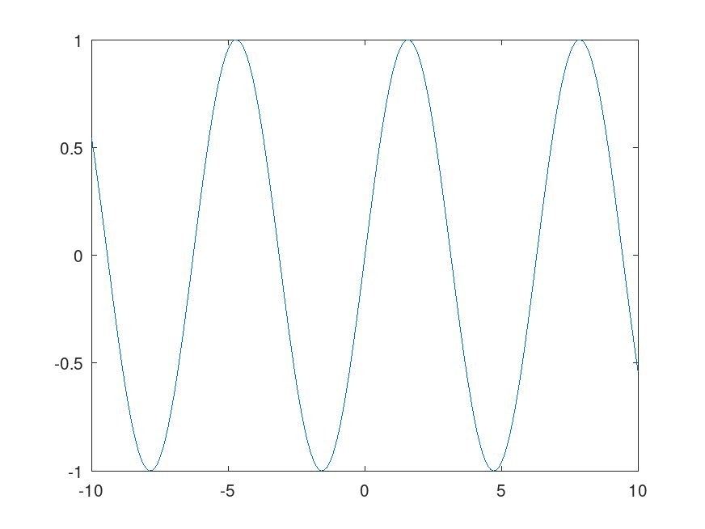

To reuse functions etc you can source the created source code files into subsequent code blocks.

### R scripts

Now an example for an R-script and how functions created in one code chunk can be reused in an other code chunk.

````
    ```{.cmd file="plot.R" eval=false results=hide cachedir="."}
    #!/usr/bin/env/Rscript
    doPlot = function (x,y,pch=19,col="red",...) {
       plot(y~x,pch=pch,col=col,...)
    }
    ```
````

This is the output, just code display:

```
#!/usr/bin/env Rscript
doPlot = function (x,y,pch=19,col="red",...) {
   plot(y~x,pch=pch,col=col,...)
}
```

In the next chunk we use this function by sourcing the file.

````
    ```{.cmd file="doplot.R" results="hide" eval=true cachdir="."}
    #!/usr/bin/env Rscript
    source('plot.R') # file was created in the previous chunk.
    x=seq(0,8,by=0.1)
    y=sin(x)
    y=y+rnorm(length(y),sd=0.1)
    png("plotR.png")
    doPlot(x,y)
    dev.off()
    ```
````

And here the output:

```
#!/usr/bin/env Rscript
source('plot.R') # file was created in the previous chunk.
set.seed(123)
x=seq(0,8,by=0.1)
y=sin(x)
y=y+rnorm(length(y),sd=0.1)
png("plotR.png",width=900,height=600)
par(mfrow=c(1,2))
doPlot(x,sin(x),main="y=sin(x)")
doPlot(x,y,main="y=sin(x)+noise")
dev.off()
```

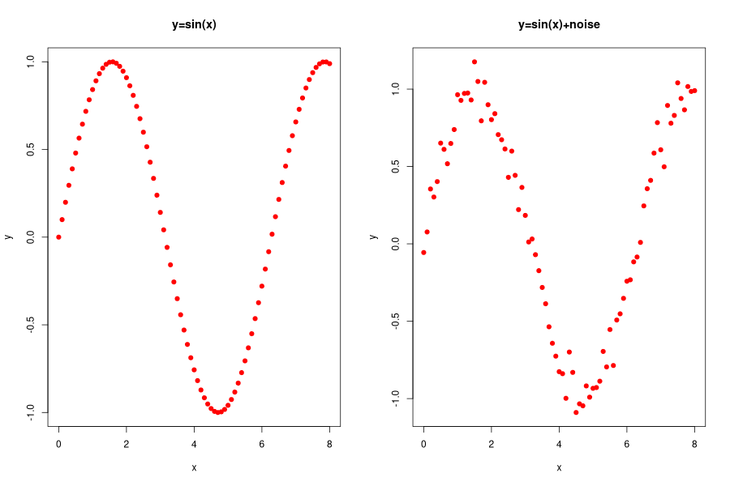

There is as well a separate filter for R called *rplot*, see filter-rplot.html. This filter supports as well session management, so that separate code chunks share the same R-session and syntax highlighting.

### Gnuplot scripts

Next a Gnuplot script (`{.cmd file="sin.gp" eval=true}`):

```
#!/usr/bin/env gnuplot
# Set the output to a png file
set terminal png size 800,500
# The file we'll write to
set output 'sin-gp.png'
# The graphic title
set title 'sin(x) - Gnuplot'
#plot the graphic
plot sin(x)
```

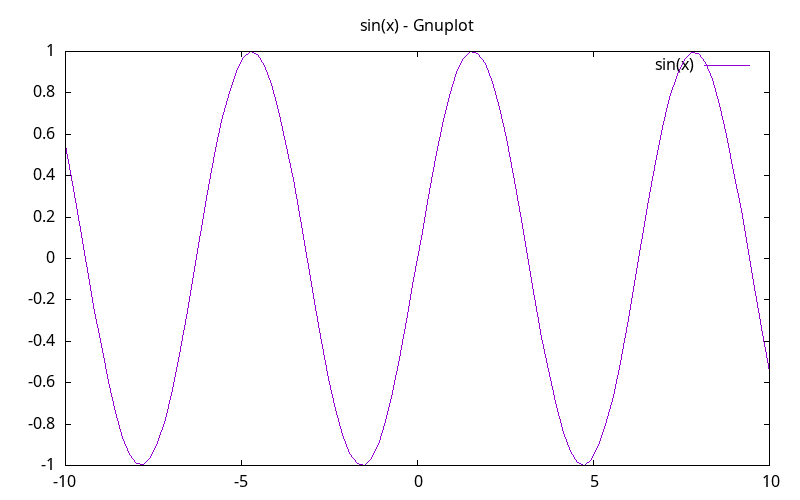

### Lua Scripts

Here a short Lua code example ({.cmd file=“factorial.lua” eval=true}):

```
#!/usr/bin/env lua
-- defines a factorial function
function fact (n)
    if n == 0 then
        return 1
    else
        return n * fact(n-1)
    end
end
print(fact(5))
```

```
120
```

### GraphViz dot scripts

Here an example for a standalone dot-script (`{.cmd file="digraph.dot" eval=true}`):

```
#!/usr/bin/env -S dot -Tpng -odot.png
digraph G {
  node[style=filled,fillcolor=skyblue];
  A -> B ;
}
```

And now an example doing plots with Gnuplot:

```
#!/usr/bin/env gnuplot
# Set the title for the graph.
set title "Gnuplot Sine against Phase"

# We want the graph to cover a full sine wave.
set xrange [0:6.28]

# Set the label for the X axis.
set xlabel "Phase (radians)"
# Unicode for pi
set xtics ("0" 0,"0.5\U+03C0" pi/2, "\U+03C0" pi, \
    "1.5\U+03C0" 1.5*pi, "2\U+03C0" 2*pi)

# Draw a horizontal centreline.
set xzeroaxis

# Pure sine wave amplitude ranges from +1 to -1.
set yrange [-1:1]

# No tick-marks are needed for the Y-axis .
unset ytics

set terminal png
set output 'images/test.png'
# Plot the curve.
plot sin(x)
```

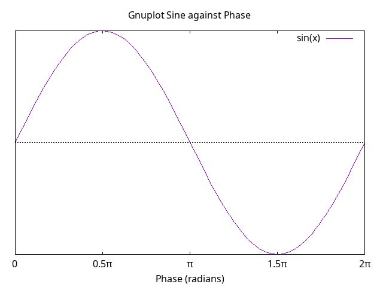

### Simple shell scripts

First a mathematical calculation (`{.cmd file="calc.sh" eval=true}`):

```
#!/bin/sh
x=6
y=7
echo $(($x+$y))
```

```
13
```

Then a mathematical equation (`{.cmd file="math.eqn" eval=true}`):

```
#!/bin/sh
echo "x = {-b +- sqrt{b sup 2 - 4ac}} over 2a" \
      | eqn2graph -colorspace RGB -density 144 > eqn.png
```

[output not shown]

And here let’s use this for the formula of the most important biochemical reaction on planet Earth (`{.cmd file="photo.eqn" eval=true}`):

```
#!/bin/sh
echo "6H sub 2 O + 6CO sub 2 + Light -> C sub 6 H sub 12 O sub 6 + 6 O sub 2" \
      | eqn2graph -colorspace RGB -density 144 > photo.png
```

[output not shown]

Afterwards you can embed the png image using your Markdown code.

For more information on how to typeset equations using the EQN syntax have a look here: https://www.oreilly.com/library/view/unix-text-processing/9780810462915/Chapter09.html.

### Lilypond example

A typical problem are programming languages which do not support the shebang line. We can create for such languages a wrapper script which pipe the input of a script but not the very first line into the interpreter. Here an example for the lilypond interpreter, a tool to process music notation. Here the wrapper script:

```
#!/usr/bin/env bash
# file: lilyscript.sh
if [ -z $2 ]; then
    out=out.svg
    ext=svg
else
    out=$2
    ext=${out##*.}
    out=`basename $out .$ext`
fi
# echo all lines bit not the shebang line and
# pipe this into lilypond
# crop page
echo "
\version \"2.14.1\"
" > temp.ly
perl -ne '$x++ >= 1 and print' $1 >> temp.ly
echo "
\paper {
  indent = 0\mm
  line-width = 110\mm
  oddHeaderMarkup = \"\"
  evenHeaderMarkup = \"\"
  oddFooterMarkup = \"\"
  evenFooterMarkup = \"\"
}
\header { tagline = \"\" }
" >> temp.ly
lilypond --$ext --output=$out  temp.ly
if [ -e "$out-systems.texi" ]; then
     rm $out-*
fi
# EOF
```

If we copy this file as lilyscript.sh into a folder belonging to our PATH variable we can then embed lilypond code into a executable script easily. Here an example (chunk options are: `{.cmd file="mini.ly" results="hide" eval=true cachdir="."}`):

**Please note** that this script above creates a few intermediate files, so you need to set the cachedir usually to the current folder by adding the option **`cachedir="."`** to your code chunk to get this working.

```
#!/usr/bin/env -S lilyscript.sh mini.ly mini.svg
#(set! paper-alist
  (cons '("my size" . (cons (* 3 in) (* 0.8 in))) paper-alist))
\paper {  #(set-paper-size "my size") }
{
  % middle tie looks funny here:
  <c' d'' b''>8. ~ <c' d'' b''>8
}
```

We then embed the image using Markdown syntax. Using the border-style we can as well adapt the width and height of the paper size see if required if we add nore notes later:

```
![](mini.svg){#id width=240 style="border: 3px solid #ddd;"}
```

Gives:

[figure not shown]

Here an example for a PNG image with the settings `{.cmd file="mini2.ly" results="hide" cachedir="."}`.

```
#!/usr/bin/env -S lilyscript.sh mini2.ly mini2.png
#(set! paper-alist
  (cons '("my size" . (cons (* 3 in) (* 0.8 in))) paper-alist))
\paper {  #(set-paper-size "my size") }
{
  % middle tie looks funny here:
  <c' d'' b''>8. ~ <c' d'' b''>8
}
```

We again include the created image using standard Markdown syntax with setting as well a width to scale the image (`![](mini2.png){#id width=240}`):

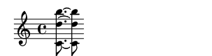

### Text Editors

Some text editors like [Jasspa MicroEmacs](http://www.jasspa.com) can be as well used for using non-interactive at the command line. Here an example for this nice text editor.

```
#!/usr/bin/bash
tail --lines=+3 $0 > temp.emf && me -n -p "@temp.emf" && exit
; below follows the MicroEmacs code
-1 ml-write "Hello Jasspa MicroEmacs World!"
-1 ml-write &cat "This is MicroEmacs " &cat $version "!"
set-variable %x 1
!while &less %x 10
    -1 ml-write &cat "x is " %x
    set-variable %x &inc %x 1
!done
quick-exit
```

```
[?7hHello Jasspa MicroEmacs World!
This is MicroEmacs 20091225b1!
x is 1
x is 2
x is 3
x is 4
x is 5
x is 6
x is 7
x is 8
x is 9
```

### C and C++ code

Using the approach with the lilypond examples we can as well embed C code by creating a wrapper for the compiler. Here we are usinfusing a pseudo- shebang line (`{.cmd file="hello2.c" eval=true}`):

```
///usr/bin/cc -o "${0%.c}" "$0" -lm && exec "${0%.c}"

#include <stdio.h>
#include <math.h>

int main (int argc, char** argv) {
    printf("Hello C Compiler World!\n");
    float pi = 3.141492653;
    printf("pi is: %f\n",pi);
    printf("sin(pi) is: %f\n",sin(pi));
    return(0);
}
```

```
Hello C Compiler World!
pi is: 3.141493
sin(pi) is: 0.000100
```

The same mechanism can be used for C++ code ({.cmd file=“hello.cxx”}):

```
///usr/bin/g++ -o "${0%.cxx}" "$0" && exec "${0%.cxx}"
#include <iostream>

int main(int argc, char** argv) {
  using namespace std;
  int ret = 0;
  cout << "Hello C++ World!" << endl;
  return ret;
}
```

```
Hello C++ World!
```

Please take care that you need to use the same file extension in your shebang line and for your file argument, if your file ends in `cpp` as well your shebang has to use not `cxx` but `cpp` in the first line, the compiler line.

Sometimes your code required other files in the same directory or in files being in relative order to the current source code, for instance if you include local header files. In this case you should set the `cachedir` property to a `.` (dot) to indicate the current working directory. Here an example using the `[popl.h](https://github.com/badaix/popl)` argument parsing library.

```
///usr/bin/g++ -o "${0%.cxx}" -I. "$0" && exec "${0%.cxx}"
#include <iostream>
#include "include/popl.hpp"

void usage (char * appname) {
    std::cout << "Usage: " << appname << " [-h, --help | -v, --verbose | -r, --rounding int]\n";
}
int main (int argc, char * argv[]) {
    popl::OptionParser app(
          "popl application\nUsage: poplex [options] number\nOptions");
    auto help   = app.add<popl::Switch>("h", "help",
          "produce help message");
    auto verbose   = app.add<popl::Switch>("v", "verbose",
          "set verbose on");
    auto round = app.add<popl::Value<int>>("r", "round",
          "rounding digits",2);
    if (argc == 1) {
        usage(argv[0]);
        return(0);
    }
    app.parse(argc, argv);
    // print auto-generated help message
    if (help->is_set()) {
        std::cout << app << "\n";
        return(0);
    } else if (verbose->is_set()) {
        std::cout << "verbose is on\n";
    }
    return(0);
}
```

```
Usage: /home/dgroth/.cache/pantcl/poplex [-h, --help | -v, --verbose | -r, --rounding int]
```

## Go, Rust and Vlang

Here an example for the Go language (`{.cmd file="hello.go"}`):

On Fedora I had to install Go with `sudo dnf install golang`.

```
///usr/bin/go run $0 $@  2>&1 && exit 0
package main

func main() {
    println("Hello Go World!")
}
```

```
Hello Go World!
```

Next try is Rust (`{.cmd file="hello-rust.rs"}`), as there is no `run` for rust we need to compile and then to execute the file as in C/C++. On Fedora I had to install Go with `sudo dnf install rust`.

```
///usr/bin/rustc $0 $@  -o ${0%.rs} 2>&1 && exec "${0%.rs}" && exit 0
fn main () {
  println!("Hello Rust World in 2024!")
}
```

```
Hello Rust World in 2024!
```

Now the new programming language [Vlang](https://vlang.io/) (V) (`{.cmd file="hello.v"}`):

```
///usr/local/bin/v run $0 $@  2>&1 && exit 0
fn main () {
  println("Hello V World in 2024!")
}
```

```
Hello V World in 2024!
```

And now the Java Programming language:

```
////usr/bin/javac $0 $@ 2>&1 && exec java -cp . HelloWorld && exit 0
class HelloWorld {
   public static void main(String[] args) {
       System.out.println("Hello, World!");
   }
}
```

```
Hello, World!
```

### Other programming languages

I left it as an exercise to embed Perl, Ruby, Julia scripts using the standard Shebang mechanism.

## Command line as chunk option

You can as well write the data into the code chunk and the command line to process this data as an chunk option, below is an example writing the Graphviz dot code within the code chunk:

```
'``{.cmd cmd="dot -Tpng -o%o %i" fig=true}
digraph g {
A -> B
}
'``
```

The placeholder *%i* is for the inut file, the placeholder *%o* for the output file. If only the basename of the input file is required you can use *%b*.

And here is the output:

```
digraph g {
A -> B
}
```

Let’s use *%b* to create an SVG file.

```
'``{.cmd cmd="dot -Tsvg -o%b.svg %i" fig=true ext="svg"}
digraph g {
A -> B
}
'``
```

Output:

```
digraph g {
A -> B
}
```

[figure not shown]

In case you would like to change the command line but not the code chunk data you can use the place holder “LASTFILE” in the code chunk, here an example:

```
'``{.cmd cmd="dot -Tsvg -Nshape=box -Grankdir="LR" -Nstyle=filled -Nfillcolor=salmon -o%b.svg %i" fig=true ext="svg"}
LASTFILE
'``
```

Output:

```
LASTFILE
```

[figure not shown]

Obviously in the example above it might be easier to place the node and graph properties directly into the dot code. But sometimes there might be reasons, especially if the code chunk text is very long to change a few command line options. An example for this would be for instance a Go game where you would like to hilight different phases of the game. Here an example of a 13x13 game where the LASTFILE place holder makes really sense. We use the command line tool sgf-render with the following code chunk options:

````
'``{.cmd cmd="sgf-render %i --format png --outfile %o --width 500 --move-numbers=1-10 -n 10" echo=true fig=true}
... sgf coce
'```
````

Here the output (usually we would hide the sgf code by using *echo=false*.

```
(;FF[4]
CA[UTF-8]
GM[1]
DT[2025-02-28]
GN[Freundschaftsspiel]
PB[Black Player]
PW[White Player]
BR[15k]
WR[14k]
TM[432000]OT[86400 fischer]
RE[W+9.5]
SZ[13]
KM[6.5]
RU[Japanese]
;B[jj]
(;W[dd]
(;B[jc]
(;W[dj]
(;B[je]
(;W[hk]
(;B[ik]
(;W[hj]
(;B[cc]
(;W[cd]
(;B[dc]
(;W[ec]
(;B[eb]
(;W[fc]
(;B[bd]
(;W[fb]
(;B[db]
(;W[be]
(;B[ac]
(;W[cf]LB[cg:A][eg:B]SQ[dj][jj]CR[hj]
(;B[ck]
(;W[cj]
(;B[dk]
(;W[ek]
(;B[el]
(;W[fk]
(;B[fl]
(;W[kg]
(;B[jh]
(;W[jg]
(;B[kh]
(;W[hg]
(;B[bj]
(;W[bi]
(;B[bk]
(;W[le]
(;B[ld]
(;W[kd]
(;B[lg]
(;W[lf]
(;B[lh]
(;W[lc]
(;B[kc]
(;W[jd]
(;B[lb]
(;W[md]
(;B[ic]
(;W[id]
(;B[hc]
(;W[gd]
(;B[hd]
(;W[he]
(;B[gc]
(;W[fd]
(;B[ij]
(;W[hi]
(;B[ih]
(;W[hh]
(;B[hl]
(;W[ha]
(;B[hb]
(;W[ga]
(;B[ia]
(;W[gb]
(;B[jb]
(;W[mb]
(;B[la]
(;W[gl]
(;B[ig]
(;W[if]
(;B[gm]
(;W[gk]
(;B[im]
(;W[aj]
(;B[ak]
(;W[ai]
(;B[mf]
(;W[ae]
(;B[bb]
(;W[ad]
(;B[bc]
(;W[mc]
(;B[ii]
(;W[me]
(;B[mg]
(;W[ea]
(;B[da]
(;W[fa]
(;B[dl]
(;W[ma]
(;B[]
(;W[]
))))))))))))))))))))))))))))))))))))))))))))))))))))))))))))))))))))))))))))))))))))))))))))
```

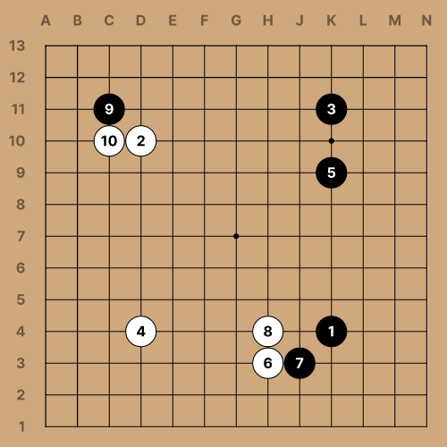

To reuse the content above we can use:

```
'``{.cmd cmd="sgf-render %i --format png --outfile %o --width 500 --move-numbers=11-20 -n 20" echo=true fig=true}
LASTFILE
'``
```

Output:

```
LASTFILE
```

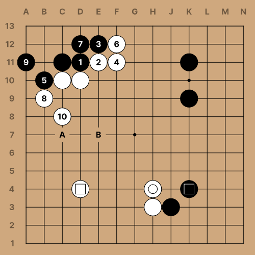

## See also:

- Pantcl Readme
- Pantcl docu
- Pantcl tutorial
- Abc filter
- GraphViz dot filter
- Rplot filter
- Pipe filter for Python, R, Octave